# Pre-processing ASVs with Phyloseq

Shawn Xinyu Wang

April 15, 2025

# Goals

First, we will use the [phyloseq package](https://joey711.github.io/phyloseq/) to combine all of our data objects that we exported from the DADA2 workflow (`asv_table`, `tax_table`, and metadata) and incorporate them into a single [specialized S4 R Data object](https://adv-r.hadley.nz/s4.html), known as a phyloseq object. Then, we will remove any potential contaminants and evaluate the accuracy of our sequencing run. Finally, we will write our our single `raw_preprocessed_physeq` phyloseq data object.

## Specific Steps:

1. Load in data that we’ve generated in `analysis/02_AssignASVs.Rmd` and fix all of the names to match each other. *The names must match for us to incorporate them into the S4 phyloseq object*:
   1. `asv_table`: ASVs (rows) x Samples (columns)
   2. `tax_table`: ASV (rows) x Taxonomy (columns)
   3. `metadata`: Samples (rows) x All our data (*e.g. pH, Temp, treatment group, etc*; columns)
2. Combine the data into a phyloseq object.
3. Remove any contaminating ASVs that are **chloroplasts**.
4. Remove ASVs that are **mitochondria**.
5. Evaluate any ASVs from the **negative controls**. Then, remove negative controls.
6. Evaluate the mock community or **positive control** to learn the accuracy of sequencing.
7. Check for **reverse complements**.
8. Check the **sequencing depth** of samples. Remove samples that obviously have too few reads.
9. Write a `raw_preprocessed_physeq` to be used in the next step of our workflow.

## Input

1. **Metadata**: `metadata.csv` and `data/01_DADA2/track_read_counts.RData`.
2. **ASV table**: `data/01_DADA2/ASV_table.csv`
3. **Taxonomy Table**: `data/01_DADA2/ASV_taxonomy.tsv`

## Output

1. A **pre-processed S4 phyloseq object**: `raw_preprocessed_physeq.RData`.

# Set Environment

## Load Packages

```r
#install.packages("BiocManager")
#BiocManager::install("Biostrings")

# NOTE, you will need to install the following 2 packages to re-create the negative control plots below!
#install.packages("ggpubr")
#install.packages("rstatix")

# Load packages with pacman
# Be sure that you load dada2 & Patchwork, which we didn't do in class on March 12th
pacman::p_load(devtools, phyloseq, dada2, patchwork, Biostrings, tidyverse, ggpubr, rstatix, install = FALSE)
```

## Timing of this script

Let’s record how long this file took to run on the class server, which we will record at the end of the script.

```r
# What time did we start running this script?
start_time <- Sys.time()
```

## 1. Load Data

### 1a. Metadata

```r
# Read metadata.csv where the first column contains sample names
metadata_df <-
  read_csv("data/metadata.csv", show_col_types = FALSE) %>%
  dplyr::rename(sample_names = Run) %>%
  mutate(names = sample_names)

# Inspect the metadata
head(metadata_df)
```

```
## # A tibble: 6 × 48
##   sample_names ReleaseDate         LoadDate              spots     bases
##   <chr>        <dttm>              <dttm>                <dbl>     <dbl>
## 1 SRR13060084  2020-11-14 10:24:18 2020-11-14 10:18:07   40956  15563280
## 2 SRR13060083  2020-11-14 10:24:18 2020-11-14 10:17:55   38758  14728040
## 3 SRR13060082  2020-11-14 10:24:18 2020-11-14 10:17:52   37188  14131440
## 4 SRR13060081  2020-11-14 10:24:18 2020-11-14 10:18:07   50118  19044840
## 5 SRR13060080  2020-11-14 10:24:18 2020-11-14 10:18:01   43447  16509860
## 6 SRR13060086  2020-11-14 10:24:18 2020-11-14 10:19:12 2550092 698643669
## # ℹ 43 more variables: spots_with_mates <dbl>, avgLength <dbl>, size_MB <dbl>,
## #   AssemblyName <lgl>, download_path <chr>, Experiment <chr>,
## #   LibraryName <chr>, LibraryStrategy <chr>, LibrarySelection <chr>,
## #   LibrarySource <chr>, LibraryLayout <chr>, InsertSize <dbl>,
## #   InsertDev <dbl>, Platform <chr>, Model <chr>, SRAStudy <chr>,
## #   BioProject <chr>, Study_Pubmed_id <lgl>, ProjectID <dbl>, Sample <chr>,
## #   BioSample <chr>, SampleType <chr>, TaxID <dbl>, ScientificName <chr>, …
```

```r
dim(metadata_df)
```

```
## [1] 407  48
```

```r
# Load the RData object that contains read tracking info
load("data/01_DADA2/track_read_counts.RData")

# Check structure and dimensions
glimpse(track_counts_df)
```

```
## Rows: 173
## Columns: 6
## $ sample_names <chr> "SRR13060060_1_filtered.fastq.gz", "SRR13060061_1_filtere…
## $ denoisedF    <dbl> 18482, 59815, 22760, 19115, 20407, 21974, 25134, 31153, 2…
## $ denoisedR    <dbl> 18548, 59907, 22941, 19197, 20479, 22073, 25248, 31202, 2…
## $ merged       <dbl> 18007, 58709, 21370, 18558, 19909, 21217, 23368, 28773, 2…
## $ nochim       <dbl> 15047, 45533, 18263, 11564, 16817, 17947, 22631, 27430, 2…
## $ num_ASVs     <dbl> 35, 40, 85, 42, 31, 27, 51, 23, 40, 14, 100, 84, 47, 45, …
```

```r
dim(track_counts_df)
```

```
## [1] 173   6
```

```r
# Remove suffix from sample names in track_counts_df
track_counts_df$sample_names <- sapply(strsplit(track_counts_df$sample_names, "_"), `[`, 1)

# Intuition check on cleaned sample names
head(track_counts_df$sample_names)
```

```
## [1] "SRR13060060" "SRR13060061" "SRR13060062" "SRR13060065" "SRR13060066"
## [6] "SRR13060067"
```

```r
# Check for unmatched sample names between metadata and track_counts
setdiff(track_counts_df$sample_names, metadata_df$sample_names)
```

```
## character(0)
```

```r
# Join metadata and tracking info, and convert to rownames
metadata_final_df <-
  metadata_df %>%
  semi_join(track_counts_df, by = "sample_names") %>%
  left_join(track_counts_df, by = "sample_names") %>%
  column_to_rownames(var = "sample_names")


# Final check on merged metadata
dim(metadata_final_df)
```

```
## [1] 173  52
```

### 1b. ASV Table

```r
# Load the ASV table generated from DADA2
asv_df <- read.delim("data/01_DADA2/ASV_table.tsv",
                     sep = "\t",
                     header = TRUE,
                     row.names = 1)

# Clean column names by removing X prefix and extracting SRR IDs
colnames(asv_df) <- gsub("^X", "", colnames(asv_df))  # Remove R-added X prefix
colnames(asv_df) <- sapply(strsplit(colnames(asv_df), "_"), `[`, 1)  # Keep only SRR ID before "_"

# Intuition check for sample names
head(colnames(asv_df))
```

```
## [1] "SRR13060060" "SRR13060061" "SRR13060062" "SRR13060065" "SRR13060066"
## [6] "SRR13060067"
```

### 1c. Taxonomy Table

```r
tax_df <-
  read.delim("data/01_DADA2/ASV_taxonomy.tsv", sep = "\t",
           header = TRUE, row.names = 1)

# Inspect
dim(tax_df)
```

```
## [1] 1207    7
```

```r
dim(asv_df)
```

```
## [1] 1207  173
```

```r
# Add check
stopifnot(rownames(asv_df) == rownames(tax_df))
```

# 2. Handoff to phyloseq

This is where we will combine our metadata, asv count table, and taxonomy table into a single data S4 data object in R, which we will call `raw_physeq` for now.

```r
raw_physeq <-
  phyloseq(otu_table(asv_df, taxa_are_rows = TRUE),
         sample_data(metadata_final_df),
         tax_table(as.matrix(tax_df)))

# Check out
raw_physeq
```

```
## phyloseq-class experiment-level object
## otu_table()   OTU Table:         [ 1207 taxa and 173 samples ]
## sample_data() Sample Data:       [ 173 samples by 52 sample variables ]
## tax_table()   Taxonomy Table:    [ 1207 taxa by 7 taxonomic ranks ]
```

```r
# save
save(raw_physeq, file = "data/03_PreProcessing/raw_physeq.RData")
```

## 3. Remove chloroplasts

```r
noChloros_physeq <-
  raw_physeq %>%
  subset_taxa(Order != "Chloroplast" | is.na(Order))

# How many ASVs were chloroplasts?
numChloros_ASVs <- ntaxa(raw_physeq) - ntaxa(noChloros_physeq)
```

There were 0 ASVs that were chloroplasts.

## 4. Remove Mitochondria

```r
noChlorosMitos_physeq <-
  noChloros_physeq %>%
  subset_taxa(Family != "Mitochondria" | is.na(Family))

# How many ASVs were mitochondria?
numMitos_ASVs <- ntaxa(noChloros_physeq) - ntaxa(noChlorosMitos_physeq)
```

There were 0 ASVs that were mitochondria in the data set.

## 5. Negative Controls

INTERPRETATION #2: There are no explicit negative or positive control samples in this dataset.

## 6. Positive Controls

INTERPRETATION #3: There is no evidence of a positive control or mock community sample in this dataset. All samples appear to be biological samples derived from human gut microbiomes. Therefore, accuracy assessment based on expected reference sequences from a mock community cannot be performed in this dataset.

## 7. Reverse Complements

```r
# Load the raw ASV table to get DNA sequences
asv_table_raw <- read.delim("data/01_DADA2/ASV_table_raw.tsv",
                            sep = "\t", check.names = FALSE)
asv_seqs <- colnames(asv_table_raw)  # These are actual DNA sequences

# Generate ASV IDs
asv_ids <- sprintf("ASV_%04d", seq_along(asv_seqs))
names(asv_seqs) <- asv_ids

# Convert to DNAStringSet and compute reverse complements
library(Biostrings)
asv_dna <- DNAStringSet(asv_seqs)
asv_rev <- reverseComplement(asv_dna)

# Compare each ASV to reverse complement of others
match_matrix <- outer(as.character(asv_dna),
                      as.character(asv_rev),
                      FUN = "==")
diag(match_matrix) <- FALSE

# Count matches
num_rev_complement_pairs <- sum(match_matrix) / 2
cat("Number of reverse complement ASV pairs:", num_rev_complement_pairs, "\n")
```

```
## Number of reverse complement ASV pairs: 0
```

```r
# Show matched pairs (if any)
matched_pairs <- which(match_matrix, arr.ind = TRUE)
matched_pairs <- matched_pairs[matched_pairs[,1] < matched_pairs[,2], , drop = FALSE]

head(data.frame(
  ASV1 = names(asv_dna)[matched_pairs[,1]],
  ASV2 = names(asv_dna)[matched_pairs[,2]]
), 5)
```

```
## [1] ASV1 ASV2
## <0 rows> (or 0-length row.names)
```

INTERPRETATION #4: No reverse complement ASV pairs were detected in the dataset.

## 8. Sequencing Depth

```r
# Load your cleaned phyloseq object
noChlorosMitosNegPosControls_physeq <- raw_physeq

# Calculate library size / sequencing depth for each sample
seqSums_df <-
  noChlorosMitosNegPosControls_physeq %>%
  otu_table() %>%
  colSums() %>%
  data.frame() %>%
  rownames_to_column(var = "SampleID")

# Rename second column to "TotalSeqs"
colnames(seqSums_df)[2] <- "TotalSeqs"

# Quick checks
dim(seqSums_df)
```

```
## [1] 173   2
```

```r
head(seqSums_df)
```

```
##      SampleID TotalSeqs
## 1 SRR13060060     15047
## 2 SRR13060061     45533
## 3 SRR13060062     18263
## 4 SRR13060065     11564
## 5 SRR13060066     16817
## 6 SRR13060067     17947
```

```r
# Sort to inspect low-depth samples
seqSums_df %>%
  arrange(TotalSeqs) %>%
  head(10)
```

```
##       SampleID TotalSeqs
## 1  SRR13060317      3827
## 2  SRR13060190      4649
## 3  SRR13060361      5733
## 4  SRR13060318      6807
## 5  SRR13060373      7320
## 6  SRR13060401      7389
## 7  SRR13060217      8039
## 8  SRR13060380      8399
## 9  SRR13060357      9594
## 10 SRR13060404     10047
```

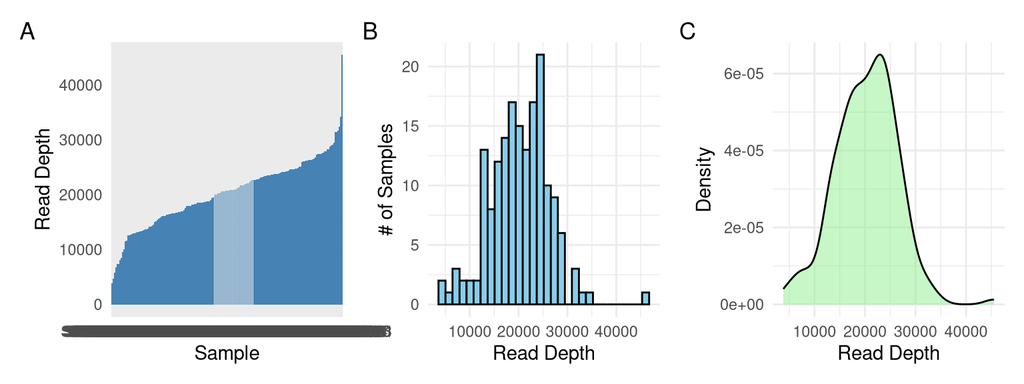

```r
# Bar plot showing sequencing depth per sample
numSeq_bar_plot <-
  seqSums_df %>%
  ggplot(aes(x = reorder(SampleID, TotalSeqs), y = TotalSeqs)) +
  geom_bar(stat = "identity", fill = "steelblue") +
  theme(axis.text.x = element_blank()) +
  labs(y = "Read Depth", x = "Sample") +
  theme_minimal()

# Histogram of total read depth across all samples
numSeq_hist_plot <-
  seqSums_df %>%
  ggplot(aes(x = TotalSeqs)) +
  geom_histogram(fill = "skyblue", color = "black", bins = 30) +
  labs(x = "Read Depth", y = "# of Samples") +
  theme_minimal()

# Density plot of sequencing depth distribution
numSeq_density_plot <-
  seqSums_df %>%
  ggplot(aes(x = TotalSeqs)) +
  geom_density(fill = "lightgreen", alpha = 0.5) +
  labs(x = "Read Depth", y = "Density") +
  theme_minimal()

# Combine all three plots
numSeq_bar_plot + numSeq_hist_plot + numSeq_density_plot +
  patchwork::plot_annotation(tag_levels = "A")
```

INTERPRETATION #5: The sequencing depth across samples is generally sufficient, with most samples having 15,000–45,000 reads. The distribution is unimodal and consistent, indicating uniform sequencing quality. While a few samples have fewer than 10,000 reads, which may limit analytical resolution, the majority are suitable for downstream 16S analysis. Low-depth samples should be considered for removal to maintain data robustness.

# Check whether need to remove samples with low reads

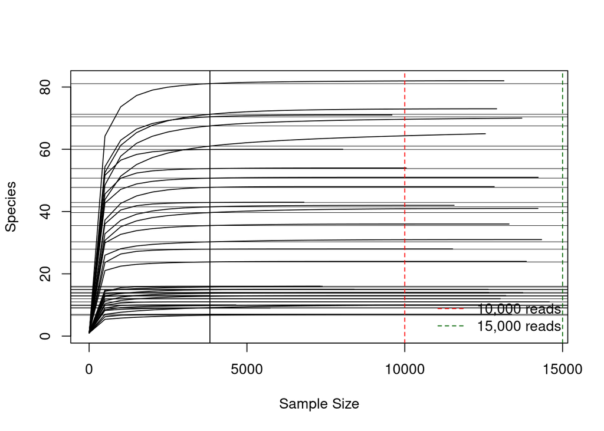

```r
# Step 1: Extract OTU table matrix from phyloseq object
otu_mat <- as(otu_table(noChlorosMitosNegPosControls_physeq), "matrix")
if (taxa_are_rows(noChlorosMitosNegPosControls_physeq)) {
  otu_mat <- t(otu_mat)
}

# Identify low-depth samples
sample_depths <- rowSums(otu_mat)
low_depth_samples <- names(sample_depths[sample_depths < 15000])

# Subset matrix
otu_low_mat <- otu_mat[low_depth_samples, ]

# Rarefaction plot using vegan
library(vegan)
rarecurve(otu_low_mat,
          step = 500,
          sample = min(rowSums(otu_low_mat)),
          cex = 0.5,
          label = FALSE)

# Optional: Add reference lines
abline(v = 10000, col = "red", lty = 2)
abline(v = 15000, col = "darkgreen", lty = 2)
legend("bottomright", legend = c("10,000 reads", "15,000 reads"),
       col = c("red", "darkgreen"), lty = 2, bty = "n")
```

Based on the rarefaction curves for samples with fewer than 15,000 reads, we observe that:

Most low-depth samples have already reached a plateau, indicating that the majority of ASV diversity has been captured even at relatively low sequencing depths.

No samples appear severely undersampled — even those below 10,000 reads show clear curve flattening.

Therefore, there is no strong justification for removing any samples at this point. All samples contain sufficient sequencing depth to capture meaningful diversity.

Thus, we will retain all samples and proceed with downstream analysis, potentially using a rarefaction depth cutoff around 10,000–12,000 reads, balancing diversity retention and sample inclusion.

## Remove samples with few reads

```r
# What's the min seq depth?
#min(sample_sums(noChlorosMitosNegPosControls_physeq))

# Remove 20210615-MA-SCB2F
raw_preprocessed_physeq <-
  noChlorosMitosNegPosControls_physeq# %>%
#  subset_samples(., names != "20210615-MA-SCB2F")

#What's the new min seq depth?
#min(sample_sums(raw_preprocessed_physeq))

# Final check of the sequencing depth for now
# Here, we could remove more samples if we needed to
#seqSums_df %>%
#  dplyr::select(names, TotalSeqs) %>%
#  arrange(TotalSeqs) %>%
#  head(n = 10)
```

# 9. Save Output

## Raw Preprocessed Phyloseq Object

Finally, let’s save our phyloseq object, which we will use for the next step!

```r
save(raw_preprocessed_physeq, file = "data/03_PreProcessing/raw_preprocessed_physeq.RData")
```

# Final info for Reproducibility

## Check Render Time

```r
# Take the time now that we are at the end of the script
end_time <- Sys.time()
end_time
```

```
## [1] "2025-04-15 11:53:39 EDT"
```

```r
# Echo the elapsed time
elapsed_time <- round((end_time - start_time), 3)
elapsed_time
```

```
## Time difference of 3.73 secs
```